# Bahrain Grand Prix Fantasy League Report

sabah alkhayr ya mudirin and welcome to the race report for the 2025 Formula 1 Bahrain Grand Prix, and the Fantasy League report, of course. The Bahrain Grand Prix is now one of the oldest circuits on the calendar, first hosting a Grand Prix in 2004, and more importantly never being resurfaced. Which means the road surface is older than some of the drivers on the grid, yep that's quite a staggering statistic. The Bahrain Grand Prix has recently hosted the opening round, and preseason testing, for many years, but has been moved to later in the year this year to accommodate a bigger push for environmental travel and Ramadan. We have seen some absolute classic races in Bahrain, even in the more recent wide-cars era of F1. Who can forget Lewis vs Max in 2021, the race that set the scene for that entire season. And of course, the next year in 2022 with Max vs Charles, the two trading overtakes into turn 1 throughout most of the race. As they like to show in the opening credits, turn 1 was also the location of the Gutierrez and Maldonado crash, with the Mexican driver completing the full 360 flip over the front wheel of Maldonado's Lotus. Bahrain, most importantly, is a wide circuit with a good variety of fast corners and hard braking zones, allowing cars to follow, overtake, and run side-by-side in many areas of the circuit, so we were expecting a good race. Let's get into it.

## The News

### McLaren's Impending Headache

McLaren are clearly the current favorites on the grid, with the reigning constructors' champions securing a podium at every single race this year, and a double podium at every race barring Australia, where we can safely assume that they would have finished 1-2 without the spin on dry tyres for Piastri. Everyone and their dog is hailing them as the team to beat in 2025, and it's certainly looking that way, even after Max Verstappen secured the win in Suzuka. Post-Japan, they were slated in the press, and even in this fantasy league, for not trying anything during the race to take the fight to Max when they had a 2-car advantage to the reigning world champion. Andrea Stella came out this week and stated that "The problem for Lando would be that he would have lost positions to some other cars, including Oscar because they had pitted and were faster". But the real issue facing McLaren is not their tyre strategy, because let's be honest, finishing the way they are all season will result in another constructors' title when the flag drops in Abu Dhabi. Their real problem is their lack of team orders, or willingness to try using team orders to better their race position. It's a problem we have seen with McLaren since Piastri joined the team, with the Woking outfit stating that both drivers are free to race and hold equal status as far as they are concerned.

We have seen McLaren execute a series of progressively more confusing team orders throughout 2024, starting with "Papaya Rules", shifting a little towards helping Norris in the fight with Red Bull but only once Piastri had agreed that he wasn't in with a shot at the title, but it has always been quite vague. 2024 Hungary springs to mind, where they told Lando to give the position back to Oscar due to a strategy call that had favored the Brit. But even at the first race of the season, in Australia, McLaren tried to implement a vague team order to prevent Oscar attacking Lando as they made it through the lapped cars, but once they had they were again free to race. If McLaren don't start trying to utilize their two-car advantage, they might find themselves being caught by the end of the season. We expect a regulation change from the Spanish Grand Prix, which should reduce the front and rear wing deflections that have been observed on the McLaren, Mercedes, and Ferrari cars in the early part of the year, in descending order of magnitude there too. Red Bull are very excited about this regulation change because they believe it will bring them back into the hunt for race victories against the three teams who are abusing this regulation. If McLaren don't use this time wisely to pull away, and consistently take points away from one another, they might find themselves being caught at the end of the season.

### Tsunoda Impresses

Yuki Tsunoda's first weekend with Red Bull was actually a lot more impressive that it looks on paper. Yuki was on pace with Verstappen in all of the practice sessions, seemingly getting to grips with the unruly Red Bull car quickly, perhaps it does indeed suit his driving style. His entire weekend, however, came undone in Q2 where he missed a lap on his new soft tyres, finished 0.5s behind Max and was eliminated. This isn't ideal, but it's an easy mistake to make, and a problem that was emphasized by the tight-nature of the modern Formula 1 grid. That does sound a little like I am pandering to Yuki, let's be fair, I have slated Lawson and Perez in these reports in the past for being just as far behind Max in qualifying. The result does not flatter the performance, particularly as overtaking in the Japanese Grand Prix was almost impossible. This one mistake in qualifying really put Yuki in a tough spot for the rest of the weekend. What is fairly impressive is that, in free air, his race pace compared to Verstappen was good; he also managed to overtake Lawson and perform a strategy overtake on Gasly, ultimately getting stuck behind Alonso, who was putting in a fairly solid performance. Despite it being his home race, and first chance to prove himself, however, Yuki did not get over confident or overly desperate in his racing, keeping a cool head and doing everything he needed to do to maximise the qualifying issue. Ultimately, if he has been 0.2 seconds faster in Q2, his entire weekend would read a very different story. It's worth noting too, that this is still the highest the second Red Bull has qualified all season, so let's just give him at last one more chance to prove himself before we start comparing him to other options.

### Aston Needs To Do Better

Many reading the headlines last year about the new Aston Martin signings will be quite surprised to see Aston Martin wallowing around at the back of the grid, only boosted slightly by the over-driving capabilities of their two-time world champion Fernando Alonso. The Spaniard finished just outside the points in Suzuka, marking his first finish of the season, after duelling with Pierre Gasly in the opening laps. Alonso said that he really enjoys the Suzuka circuit but that overtaking is difficult and the team need to improve the car performance. This was reinforced by the sudden return to form of teammate Lance Stroll, who was the first driver to pit and spent most of the race at the back of the grid, performing "important data gathering for the team". It is important to remember that the 2025 Aston Martin is the brainchild of Dan Fallows, and not that of super signing Adrian Newey. It's rumoured that Newey is entirely focused on the 2026 Aston Martin, with the team looking to maximise their budget toward the future, and perhaps even strategically maximise their wind tunnel time for the coming regulation change.

## Grand Prix Report

Something that is becoming rather irritating this season, is Lando Norris' unrelenting downplaying of the team's advantage. Many of you might remember that Lando once said, about Lewis Hamilton, "He should be winning every weekend, he has the best car and he only has to be 1 or 2 other people". Well, the media certainly remembers, and the Brit is now constantly bombarded in the media pen with questions about the performance of the car, and he must be aware of the social media presence of this quote because he came out after the first day of testing saying that "rivals didn't turn up on the first day in Bahrain". Norris stated that the key would be looking after the rear tyres, before pointing out Red Bull, Mercedes, and Ferrari and saying they had yet to show their hands over the first two sessions. It is absolutely fine to admit that you have a good car and also admit that you and your teammate are doing a good job, there is absolutely no need to consistently feel attacked just because you have a good car.

### Qualifying Report

Off to qualifying then, and everybody expected it to be a straight shootout between the two McLarens, just like it was in Australia. The usual suspects put in good laps at the start of a rather slow-to-get-going qualifying 1, with Norris and Piastri at the top, followed by Leclerc, Antonelli, and Alonso putting in some good laps early in the session. As the final laps came about, everyone started to improve on their provisional times, it very nearly came about that Verstappen and Tsunoda would be eliminated in Q1, but the Red Bull pairing managed to just do enough to secure their progression. The drivers eliminated in Q1 were Albon, Lawson who suffered with a DRS issue, Bortoleto, Stroll, and Bearman, the impressive rookie having quite the contrasting session in Bahrain to that of one week ago.

From last minute adjustments in Q1 to a crash in Q2, Esteban Ocon brought out the red flags only moments after the session really got going. The Haas driver lost control on the exit of Turn 2, sliding across the track and colliding hard with the barriers opposite those Romain Grosjean collided with not that long ago. The Frenchman reported that all was ok, but Haas were left with quite the repair job overnight to get that car into the race. The awkward timing of the red flag meant that some drivers chose to come straight out and try to get 2 timed laps in, while some opted for only 1. The problem with this, was that some of the cars came out into the pitlane before the FIA had declared it safe to do so. The medical car was in the queue of cars to leave the pits, presenting quite the unsafe environment. Those who were truly at fault were the Mercedes cars, who would later be given a 1-place penalty. Pierre Gasly managed to find a huge chunk of time and promote that Alpine into the top 10, a great effort from the Frenchman, as the team has seemed quite far off the pace in 2025 so far. Drivers eliminated in Q2 were Jack Doohan, Isack Hadjar, Fernando Alonso, Esteban Ocon, and Nico Hulkenberg. You might be quite surprised to see that Ocon wasn't last in that session, despite crashing without setting a lap time. This was something that didn't appear in the broadcast until the end of Q2, start of Q3, and it's quite embarrassing for the FIA. Nico Hulkenberg was asked not to take part in Q2 because he should have had his lap deleted in Q1 for track limits, which would have promoted Alex Albon into the Q2 session. While this wouldn't really have affected Hulkenberg's position, Alex might have been able to make it into the top 10, given his teammate made it that far in the same car.

Q3 then, and Norris and Piastri were set up for the battle for pole. A brilliant provisional lap from George Russell saw him split the McLaren drivers, with Leclerc, Hamilton, and Antonelli completing the top six. Hamilton and Antonelli both lost their provisional laps due to track limit violations, meaning the pressure was really on in the final shootout. The final push laps saw Leclerc and Mercedes take it up another notch, Russell putting it on provisional pole, Leclerc in second, and Antonelli in third. Piastri pulled it out of the bag to put his papaya machine on pole position, and Pierre Gasly put in a stunner of a lap in fifth place. Verstappen suffered with some braking issues, only managing to take seventh behind Lando Norris in sixth, with Sainz behind, and Hamilton and Tsunoda rounding out the top 10. George and Kimi were later handed their 1-place penalty, promoting Leclerc to second and Gasly to fourth place. With all the race this season having been won from pole position, and his nearest rival for the championship down in sixth place, Oscar Piastri said he "felt confident out there pretty much all weekend... I've felt really comfortable with the car. In qualifying the others caught up a little bit closer than what I wanted, but I still delivered the laps when it mattered which was the most important thing".

### Race Report

Given the abrasive road surface in Bahrain, it was quite a surprise to see most of the cars running the soft tyres, immediately this rang the alarm bells that the Bahrain Grand Prix might be a two-stopper. All that is, except the two Ferraris, Lawson, and Bortoleto, who chose to run the mediums in the first stint. Lando Norris was the big winner at the start, putting to bed some of his previous woes at the start of a Grand Prix, or so we though; the Brit wasn't in his grid box properly, and was handed a 5 second penalty as a reward. He did make it up to third at the start though, chasing down Russell. The Haas cars also looked particularly racy in the first stint, with ocon jumping up two places at the start and Bearman gaining five places.

Norris was the first of the top runners to blink and came in early to serve his penalty and change away from the soft rubber. He was followed by Gasly and Verstappen, the latter of whom suffered a particularly slow stop as the automatic light system in the Red Bull pit failed for both of their drivers. Piastri pitted a few laps later, allowing the Ferraris to assume the lead of the race. Here's where it got a bit interesting for Ferrari, as Leclerc began to ask about the possibility of doing a one-stop onto the hard compound. Unfortunately for the Monegasque, Ferrari seem to have put their wild strategies to bed lately, and Verstappen was also struggling on the hard compound, so they pitted for another set of mediums shortly after Piastri.

Drivers that were showing some serious race craft in the early phase of the race were Esteban Ocon, who pitted early and put in some incredible free-space laps to bring him into the top ten, and Kimi Antonelli; the rookie put a move on Max Verstappen that rivalled a young version of the Dutchman himself, which will definitely have gotten under his skin. The Ferraris, having extended their first stint due to a harder compound, were now flying, and a strategy of medium-medium-soft vs soft-medium-medium was playing out in front of our very eyes, finally the gods of strategy were looking favorably on us, until...

Carlos Sainz and Yuki Tsunoda came together on the apex of turn 1, the Red Bull man seemed to dive up the inside of the Williams driver, losing a little bit of friction and colliding with Sainz's sidepod. The result was a spray of carbon all over the track in that first complex of corners, leaving the race directors no choice, and they subsequently brought out the safety car. This really threw a spanner in the works of the strategy, as Antonelli had just pitted for a second time, and the Ferrari boys had no choice other than the hard tyres.

As the safety car ended, we had Piastri out front on mediums, Russell on softs, Leclerc and Hamilton on hards, and Norris on mediums. Oscar played it perfectly off the start, dropping Russell almost immediately. Leclerc however, came under pressure from Norris who was on a softer compound. The Ferrari man played it perfectly though, allowing his teammate to overtake Norris instead. Norris retaliated and overtook Hamilton off track, later having to give the place back, but the seven-time champion eventually was overtaken by the McLaren.

As the laps counted down, Leclerc put in a demonstration in defense to the championship hopeful, who eventually managed to get round the Ferrari and begin chasing down Russell. This is when things started to go a bit haywire on the broadcast. And I'd quite like a second go at moaning about it, so here we go:

- Russell's transponder for the timing system failed, and this sent the timing tower on the broadcast into meltdown. Such that, the race directors resorted to using the old optical system to display the gaps as the drivers crossed the line, this is a failsafe system they use to ensure the order is preserved in the final classification.
- Because Russell's transponder had failed, his DRS activation needed resetting into the practice/qualifying mode that allows drivers to essentially push the DRS whenever they want. Russell accidentally opened the DRS in a place he is not allowed to, whilst also not being within 1 second of the car in front. This, it turns out, was a random event as George didn't push the DRS button. Because he had gained time, he then voluntarily gave up time in the next corner.
- There's also videos of Leclerc and Norris circulating that show they had similar issues, since Norris also had to reset his DRS mode because George wasn't showing on the timing system, and therefore the activation wasn't working for Lando.
- Ultimately, George kept Lando behind him, but George was under investigation about using DRS when he wasn't supposed to. Instead of doing the investigation before the podium ceremony, we once again had to wait several hours before a confirmation of the result was provided.
- Personally, I am sick of post-race penalties ruining the enjoyment of a race. It's not hard to do a quick check on this investigation while the drivers do their awkward interviews and cool-down room shirtless pics. Anyway, rant over.

Further down the field, Sainz's damage and consequent penalties forced a retirement. Antonelli's weird strategy dropped him out of the points. Haas played a blinder and secured a double points finish. Pierre Gasly was overtaken by Max on the final lap, but we didn't see that because we were watching Lando try to get George into the last corner, despite him being too far back. Tsunoda scored his first points for Red Bull, and Nico Hulkenberg was disqualified for a skid block infringement.

## Fantasy League Scores

Scores for drivers/constructors in the current year's fantasy league, along with manager/team points, values, and statistics. Note: driver and constructor values are taken as the cost to enter the current race and are updated the week before the race.

## Lineup Scores

Race winner Oscar Piastri takes victory in the fantasy league this week, scoring a mega 45 points ahead of Lewis Hamilton, who scored 38 points thanks to gaining many places in the race. Championship leader Lando Norris takes third place this week with 32 points ahead of George Russell in fourth with 31 points. Max Verstappen and rookie sensation Oliver Bearman round out the top five with 22 points. Nico Hulkenberg suffers the disqualification hammer this week, losing 20 points and finishing last. Carlos Sainz retires from another race this season and loses 9 points. Jack Doohan puts in a reasonable performance but only brings home 2 points, behind Gabriel Bortoleto with 4 points. Fernando Alonso and Isack Hadjar round out the bottom five with 5 points.

McLaren continue their streak at the top of the constructors' weekly standings this week, bringing home a whopping 92 points ahead of Ferrari with 73 and Mercedes with 60 points. Kick Sauber suffer another disappointing week at the bottom of the table with -22 points, behind Williams with 13 and Aston Martin, who round out the bottom three with 18 points.

McLaren extend their advantage at the top of the standings, the reigning champions have 335 points to their name, ahead of Mercedes in second with 252 points and Red Bull in third with 178 points. Kick Sauber drop to the bottom of the standings with -7 points, behind Alpine with 11, and Aston Martin with 32 points.

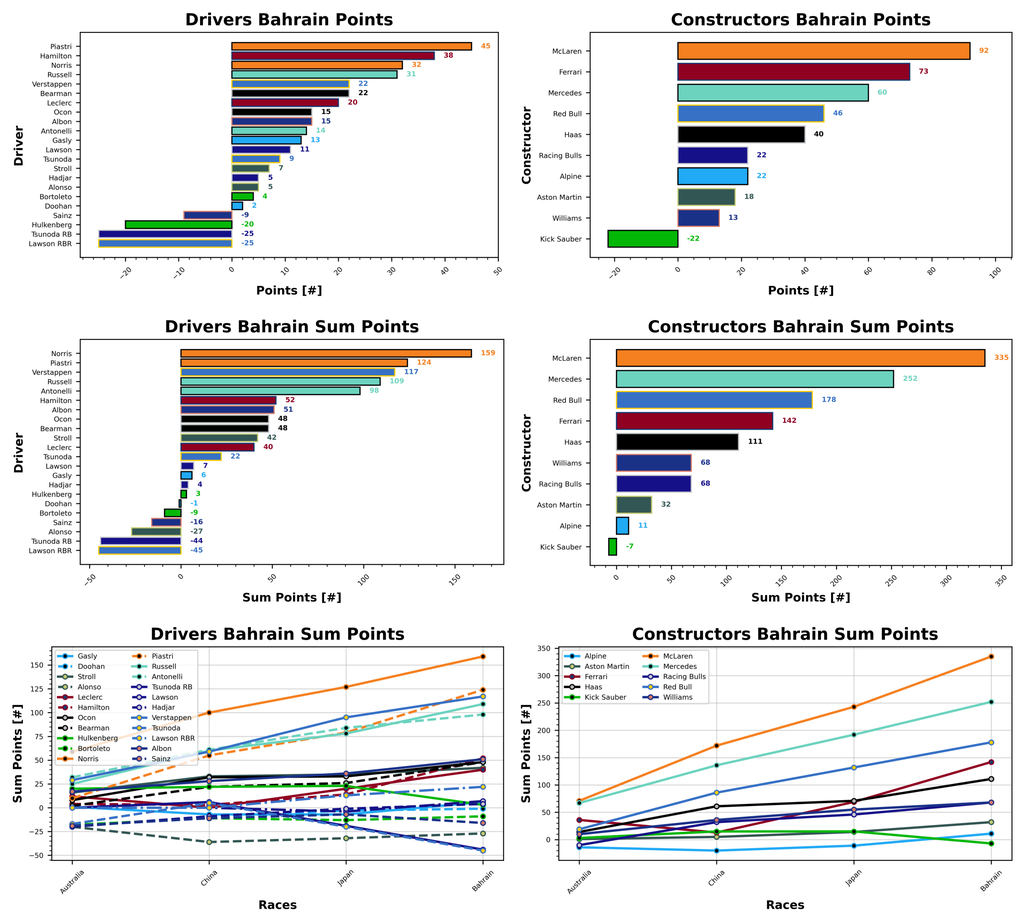

It seems the driver market has settled down a little now, and Lando Norris continues to rise in value, going into Bahrain his value was $29.9. Max Verstappen is next, increasing slightly to $28.7, ahead of Charles Leclerc with $25.0 and Lewis Hamilton with $23.3. Oscar Piastri's value increases this week to $23.1. Gabriel Bortoleto was your cheapest option this week, sitting at $4.5, behind Isack Hadjar with $4.6. Jack Doohan was your next cheapest option with a value of $5.4, behind Fernando Alonso and Oliver Bearman with values of $7.0 and $7.3.

McLaren was your most expensive constructor this week, with a value of $30.9, ahead of Ferrari at $27.0 and Red Bull at $25.7. Kick Sauber were your cheapest team this week with $6.2, behind Aston Martin with $7.1 and Alpine with $8.3.

All values are in $M.

Liam Lawson remains the worst performing driver of the season, only scoring positive points in 1 race this season. There's a mix of drivers who are 50/50, but the top 9 drivers are performing well, and are probably a good choice for your teams. Kick Sauber and Alpine are by far the worst teams you could have at the moment, only scoring positively 50% of the time.

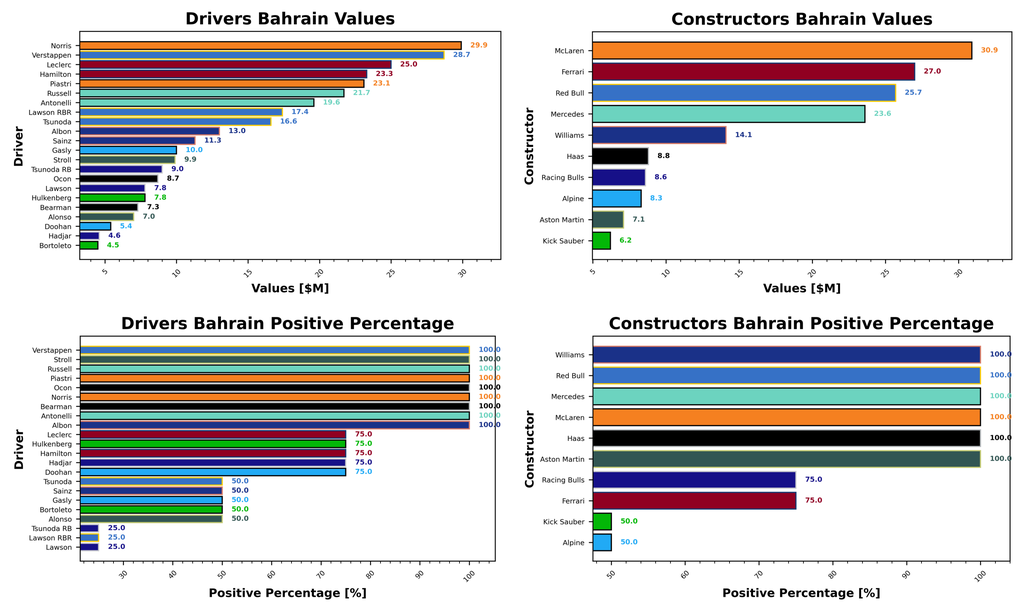

Lando Norris, championship leader, is currently averaging you 39.75 points per race, ahead of teammate Oscar Piastri who is at 31 points per race. Max Verstappen is currently scoring 29.25 points per race, ahead of the two Mercedes cars with Russell scoring 27.25 points per race and Kimi scoring 24.5 points per race. Fernando Alonso is losing 6.75 points per race, behind Carlos Sainz with -4 points per race. Bortoleto next with -2.25 points per race. Jack Doohan is averaging -0.25 points per race, and Nico Hulkenberg now sits on 0.75 points per race.

McLaren, as your championship leaders, are averaging 83.75 points per race, ahead of Mercedes with 63 points per race, and Red Bull with 44.5 points per race. Kick Sauber are scoring -1.75 points per race, behind Alpine with 2.75 points per race, and Aston Martin with 8 points per race.

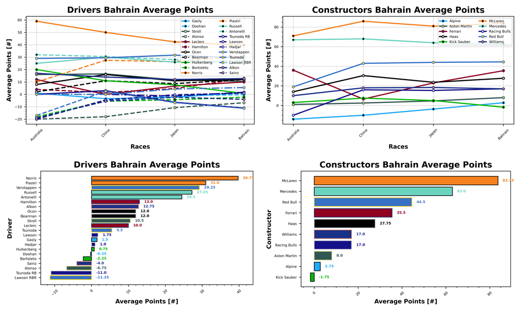

Your driver of the week this week is Oliver Bearman, who fought from last on the grid to finish in the points, and brought with it a points per value of 3.01 ppm. He's miles ahead of Oscar Piastri in second with 1.95 ppm, and his teammate Ocon in third with 1.71 ppm. Lewis Hamilton is in fourth this week with 1.63 ppm, and former teammate Russell rounds out the top five with 1.42 ppm. Nico Hulkenberg was your worst driver of the week, with -2.56 ppm, behind Carlos Sainz with -0.8 ppm. Jack Doohan is next up with 0.37 ppm, and Yuki Tsunoda was fourth with 0.54 ppm. Lance Stroll returns to type with 0.71 ppm.

A strong double points finish for Haas means they were your team of the week this week, bringing home a points per value of 4.55 ppm. McLaren were second with 2.98 ppm, and Ferrari third with 2.7 ppm. Kick Sauber were your worst team of the week with -3.55 ppm, behind Williams with 0.92 ppm, and Red Bull with 1.79 ppm.

ppm = points per million ($).

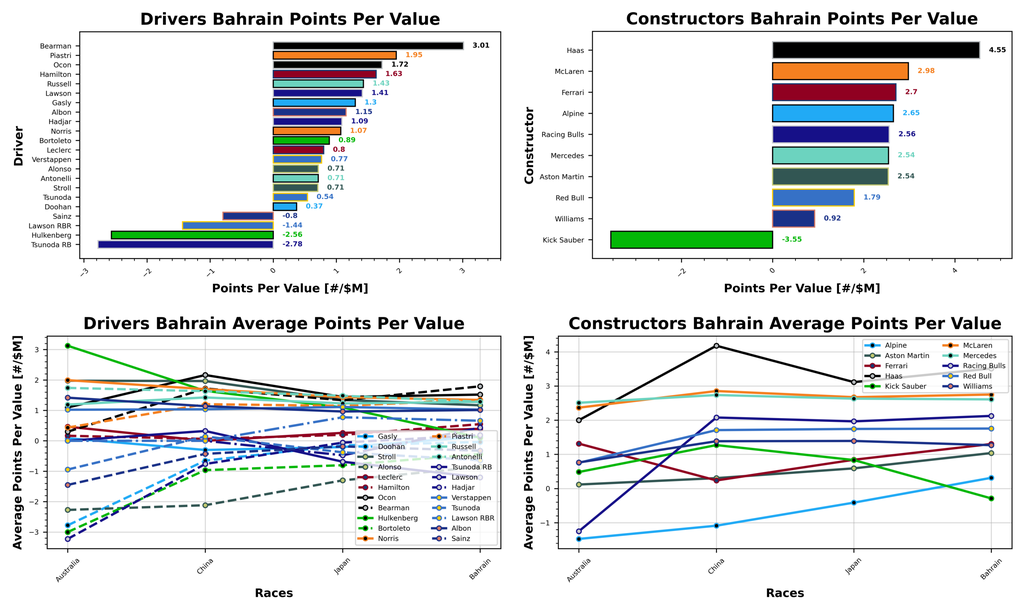

### Manager Scores

At the bottom of the table this week is rookie manager Alfie, who is benefiting/suffering with a double inactive token with their team Cucumberpotatolamborghini scoring -70 points. In second we have Valerie with Stroll To The 18th managing -18 points this week, followed by their second team What Arrrgh Ya Doohan with 2 points, and their third team Perez For World Champion with 4 points. In fourth place, it's James and Bwoah Schweppes Puma Golf and Patrick with Coming In Haast Place with 15 points each.

Stefanus sits at the top of the managers' table this week with 238.33 points, ahead of Stuart with 236 points. In third place it's Madlen with 209.67 points. The worst manager of the week was Valeria with -4 points, on average. Then it's Will with 106.67 points, and Patrick with 118.5 points. These are averages across entered teams.

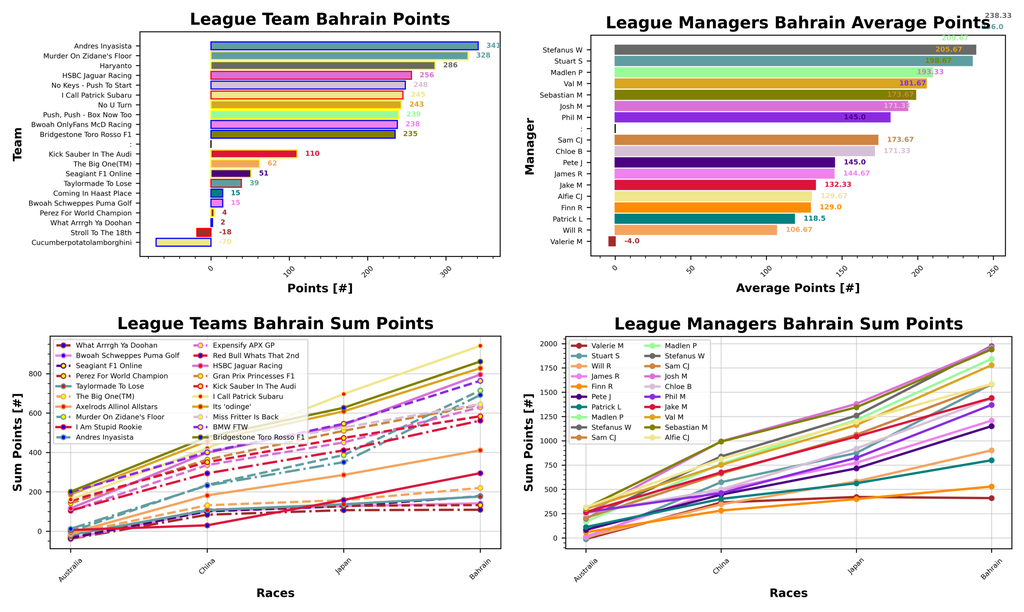

Alfie holds on to their lead at the top with I Call Patrick Subaru, now sitting clear with 948 points ahead of Sebastian and Bridgestone Toro Rosso F1 with 862 points. Val is in third place with Its "odinge" coming in at 828 points ahead of Josh in fourth with HSBC Jaguar Racing and 796 points. Phil rounds out the top five with BMW FTW, sitting on 764 points.

Our biggest winner of the week is a double-top for Stuart, who gains 13 places with Murder On Zidane's Floor and Andres Inyasista. Phil is in second, gaining 10 places with BMW Should Be Here, who are finally making some progress this season. In third, it's Chloe and Val with their teams No Keys - Push To Start and Limoncello44 who gain 7 places this week. Our biggest loser of the week is Jake, with Kick Sauber In The Audi losing 11 places. They're followed by Valerie and Stroll To The 18th losing 9 places, and Ro@d R@ge, managed by Finn, who lose 8 places this week.

Stefanus assumes the lead in the average manager points for the season, pushing up to 658.33 points, ahead of Josh and Sebastian with 653.33 and 647 points. Our worst manager of the season so far is Valerie, scoring 136.67 points this season so far. Will is next with 300.67 points, followed by pete with 383.67.

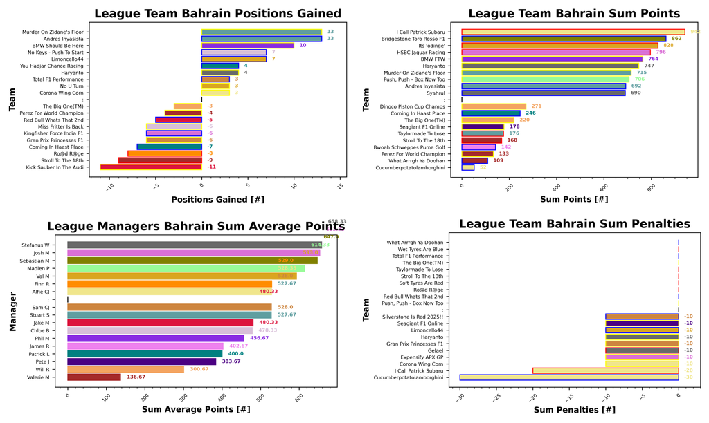

I'm not sure whether it's the price, or the fact that he is actually putting in some reasonable performances, but Isack Hadjar's popularity amongst you all increases this week. The rookie Racing Bulls driver is now in 33 of your teams. The Haas boys are next, with Bearman making 21 selections, and Ocon making 19 selections. Oscar Piastri and Gabriel Bortoleto are in fourth with 16 selections each, followed by Hulkenberg and Albon with 15 selections to round out the top five. There's a wild Lawson Red Bull token out there, with Alfie's team, but Lewis Hamilton is the least selected driver of the week, with only 2 of you holding on to the dream. More of you chose Yuki Tsunoda's inactive token than Hamilton, with the inactive making up 3 selections. The real Yuki Tsunoda is next with only 4 selections. Rounding out the least selected five is Verstappen, Leclerc, Lawson, and Gasly with 5 selections each.

McLaren are you most selected team this week, with 2 more of you selecting them, they were in 17 of your teams this week. Haas also very popular this week, making 16 selections, and Kick Sauber somehow made it into 15 of your teams. Red Bull are the least selected, only managing 3 selections, behind Alpine with 4 and Williams with 6.

Oscar Piastri is very flavour of the month at the moment, with 13 of you choosing to double his score. Lando Norris appears 11 times as your DRS boosted driver, and Gabriel Bortoleto makes 5 DRS boost selections. We had 2 limitless tokens, 1 no negative, and 1 final fix tokens used this week.

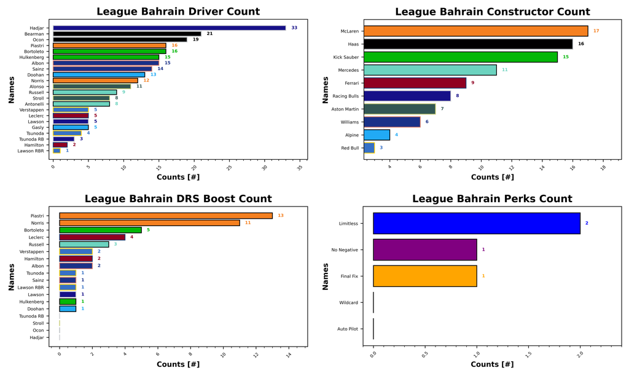

## Prizes

I have now updated the prizes plotting for my code and we should be able to track the season long prizes with ease. So without further adieu, let's take a look at what is currently in play this season.

### Championship

| Prize Name | Prize Value | Terms |
| --- | --- | --- |
|  | (%) |  |
| Champion of the World | 20 | Awarded to the top scorer in the league at the end of the season |
| If You're Not First, You're Last | 10 | Awarded to the second place scorer in the league at the end of the season |
| Alpine Podium | 5 | Awarded to the third place scorer in the league at the end of the season |
| Above Par | 20 | Awarded to the lowest scorer in the league at the end of the season, commonly referred to as the Golf League |

### Achievements

| Prize Name | Prize Value | Terms |
| --- | --- | --- |
|  | (%) |  |
| Cost Cappen | 5 | Highest average points per value at the end of the season |
| Sprint King | 5 | Highest score across the sprint races (China, Miami, Belgium, United States, Brazil, Qatar) |
| Flavio Controls Every Millimeter | 5 | Manager wide substitution count, highest wins |
| The Triple Header | 5 | Highest score across the triple header races (Japan, Bahrain, Saudi Arabia, Emilia Romagna, Monaco, Spain, Las Vegas, Qatar, Abu Dhabi) |
| I Forgot I Was Taking Part | 5 | Highest score in the first part of the season |
| Zak's Master Plan | 5 | Lowest score in the second half of the season |
| Mega Driver | 5 | Highest Extra DRS token score |
| The Continental | 5 | Highest score across all 5 continents, Mexico classed as South America for inclusion only (Australia, Canada, Great Britain, Azerbaijan, Mexico) |

### Spot Prizes

| Prize Name | Prize Value | Terms |
| --- | --- | --- |
|  | (%) |  |
| The Ring | 1 | Highest score at the Austrian Grand Prix |
| Bottas Bowling | 1 | Highest score at the Hungarian Grand Prix |
| Daniel's Broken Hand | 1 | Lowest score at the Netherlands Grand Prix |
| The Tifosi | 1 | Lowest score at the Italian Grand Prix |
| Go For The Gap | 1 | Lowest score at the Singapore Grand Prix |

### Spot Prizes

We haven't had a spot prize yet, I will post about it when we have one!

### Cost Cappen

Holding onto the lead this week is Alfie, who takes a points per value of 2.37 ppm with I Call Patrick Subaru, ahead of Sebastian with Bridgestone Toro Rosso F1 with 2.16, and Val with Its 'odinge' with 2.09 ppm. This competition will run all year, but it's nice to keep a track of it.

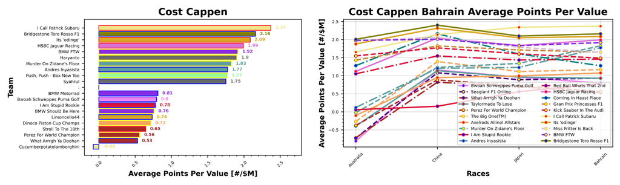

### Flavio Controls Every Millimeter

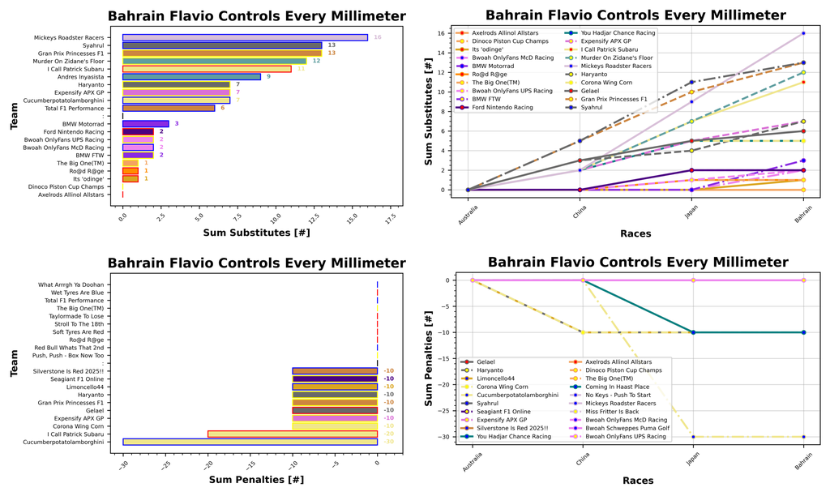

### Mega Driver

So far there have been no uses of the Extra DRS token. Check back later!

### Sprint King

Obviously no change to the Sprint King award this week. It's still Josh with HSBC Jaguar Racing out front with 283 points ahead of Sebastian and Bridgestone Toro Rosso F1 with 277 and Madlen with Push, Push - Box Now Too with 276.

```
No images found for Sprint King for Bahrain.
```

### The Continental

More To Come.

[output not shown]

### The Triple Header

We are now two weeks into the first triple header of the season. So far, Stuart and Andreas Inyasista are currently leading the way with 460 points, ahead of Stefanus and Haryanto with 427, and Josh with HSBC Jaguar Racing and 397 points.

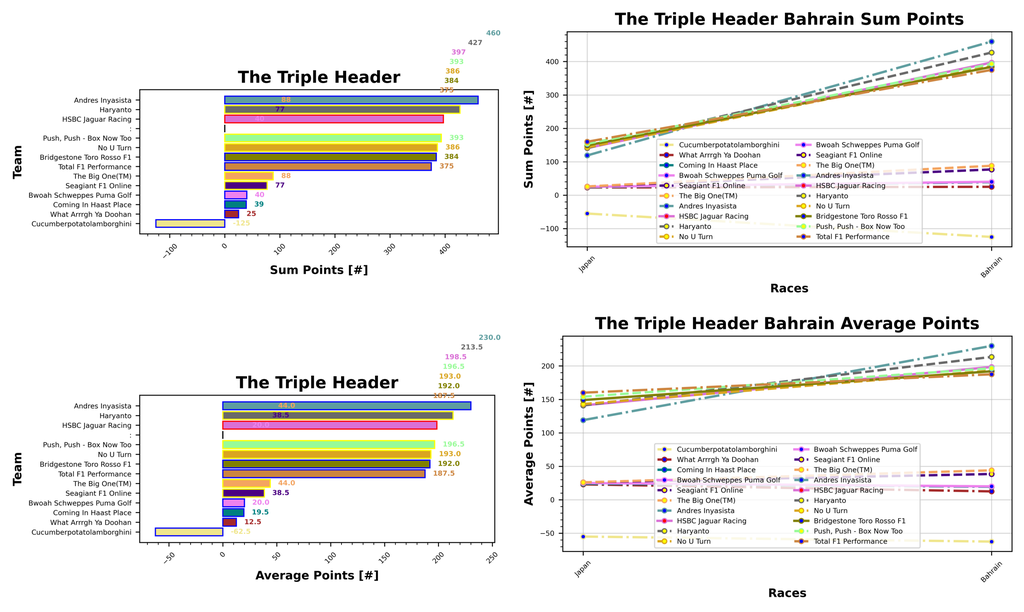

### I Forgot I Was Taking Part

Similarly, I Forgot I Was Taking Part will match up with the current championship standings.

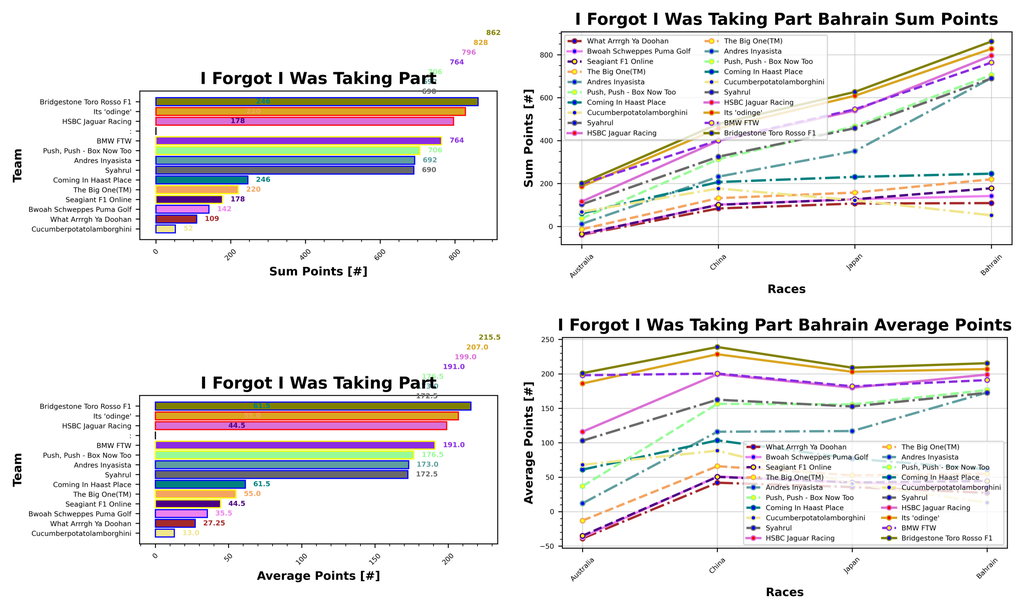

### Zak's Master Plan

Check back after the season break!

## F1 Predict

F1 predict time, I haven't quite yet sorted the plotting out for this one yet since I did my big overhaul middle of last year when everything started getting bit crazy, so bare with on the graphs for this one, I apologize.

Stuart took the victory this week with 101 points, 60% correct, ahead of Pierce with 73 points (37%) and Phil with 65 points (40%). This takes the totals up to 222 for Stuart, 198 for Pierce, and 161 for Phil in the top three. Josh is next with 160, ahead of Val with 115 and Matty with 50.

## Next Up

Next up is the Saudi Arabian GP, the third race in our first triple header. This one should be exciting if there is even a little bit of chaos, it usually just escalates from there. Best of luck to you all.